# Design of Experiments—Thinking Ahead

# Foundational Concepts

That’s the challenge of experimental design, to make sure that we gather the data in such a way that we are able to draw the meaning from the data, that we are able to use the techniques of hypothesis testing and confidence intervals, to make the mathematical kind of deductions that make logical sense and that allow us to actually infer from the data the ideas of interest.

```r
if (!caracas::has_sympy()) {
  caracas::install_sympy()
}
library(caracas)
library(sets)
library(tibble)
library(ggplot2)
library(dplyr)
```

```r
def_sym("X", "Y")

cmStats <- modules::use("CmStats.R")$cmStats
```

Ronald Fisher pioneered experimental design in the early part of the 20th century. A famous case involving Fisher is told of a tea party where a lady claimed to be able to taste a cup of tea and tell whether the milk had been poured in rst, then the tea added or whether the tea had been poured in rst, then the milk added.

**The context of the experiment and our beliefs and understanding of possible causes or lack of causes influence how we interpret experimental results.**

If we can think of no physical or chemical reason for a difference, then we might be very skeptical of the result. For example, we might think that the lady saw how Fisher filled each cup, or that someone else told her, or that the “witness” wanted to make a good story. But thinking further, one may be able to imagine a physical reason that makes the difference a reality. For example, perhaps adding milk to hot tea scalds the milk in a way that could be tasted. If we can think of no possible physical difference that is potentially detectable by the woman, then we might remain quite skeptical of her abilities even after the experiment.

**There are two types of ways we can go wrong in inferring a conclusion from an experiment:**

• A type I error is where we reject the null hypothesis when, in fact, it is true.

• A type II error is where we do not reject the null hypothesis when, in fact, it is false.

Fisher began as a statistician at an agricultural research center. When he arrived, he found there was lots of information about crop yields, rainfall, fertilizer, and so forth, but the way the information had been collected made it difficult to draw useful conclusions from the data. Many of the variables involved were confounded with each other, meaning several different aspects of the growing conditions were changing at once, so it was difficult to tell which feature was causing what result. The kind of fertilizer, the kind of soil, and the amount of water were some of the variables. To confidently assign an effect to a kind of fertilizer, for example, we need to be able to disentangle its possible effects from the effects of the other variables.

### placebo effect.

In medical experiments, real effects often come from no physical cause, and those effects must be taken into account when testing new medications; that is, we need to consider the placebo effect. The fact of a placebo effect makes testing of drugs more difficult. If we give some people a new drug for, say, curing the common cold, and they get over their colds more quickly than people who did not take a drug, was it the drug or the placebo effect that shortened the cold?

### Double-blind experiments

Double-blind experiments avoid the placebo effect. The patient, the people who directly contact the patient or administer the drug, and the people who make judgments on the progress of the patient are all blind as to whether a real drug or a placebo is being used for that patient. Any possible psychological bias, intentional or not, is removed. Double-blind experiments are the gold standard, although the other qualities of design are still important, such as random selection from the population of who will be given the drug.

### Hawthorne effect

The Hawthorne effect is another famous example of difficulty in experimental design. Studies were done of the Hawthorne Plant of the Western Electric Company in Cicero, Illinois, between 1927 and 1932 to determine the effect of lighting, humidity, and other factors on worker productivity. It was discovered that the mere fact of doing the experiments, independent of which environmental factors were being changed, had a significant positive effect on the workers’ ability to perform their tasks. Perhaps workers liked the extra attention.

### Lurking variables

Lurking variables are another challenge to good experimental designs. Lurking variables are variables that aren’t being studied or controlled for but that have an effect on experimental results. For example, suppose that data show that married people in the workforce typically have a higher income than unmarried people in the workforce. We might deduce that being married is a cause of higher income. But thinking further, we realize that married people are, on average, older; hence, they have been in the workforce longer. In this case, age is a lurking variable. Placebo effect and Hawthorne effect are also examples of lurking variables.

### Experimental design

**The hallmarks of experimental design are as follows:**

• Control: Try to control all of the variables other than the one of interest or have a fixed number of variables operate independently of each other so that the results can be disentangled.

• Randomization: Do not introduce your own bias during sample selection.

• Replication: Ensure that the experiment is replicable.

*This lecture concludes the rest part of this course. In the second part, we will look at application areas of statistics*

# Concept and Applications

## HYPOTHESIS TESTING: 2 SAMPLES, PAIRED TEST

Suppose that we want to test whether 2 samples are from the same distribution. We can look at their descriptive statistics, such as histograms or box plots, but that won’t confirm a statistical difference. We need a more formal method to determine a true difference. The goal of this lecture is to demonstrate how to determine if 2 samples are similar, meaning that they come from the same underlying distribution, or different, meaning that they come from different underlying distributions.

### 2-SAMPLE HYPOTHESIS TESTING

The chicken feed data has the weight and 6 different types of feed given to newly hatched chickens. We might ask the following question: Does the feed for chickens affect their growth? If so, which feed helps our chickens grow the largest? Which one is least effective?

If the feed and weight are independent, meaning that neither one affects the other, then the distributions of the 2 samples should be the same. In other words, no matter what feed the chickens eat, their weights should be roughly the same.

To do this in R, load the datasets library. Bring up the “chickwts” dataset using the “dataset( chickwts )” command. Let’s look at the summary statistics, so “summary( chickwts ).”

```r
summary(chickwts)
```

```
     weight             feed
 Min.   :108.0   casein   :12
 1st Qu.:204.5   horsebean:10
 Median :258.0   linseed  :12
 Mean   :261.3   meatmeal :11
 3rd Qu.:323.5   soybean  :14
 Max.   :423.0   sunflower:12
```

The weights are measured in grams after 6 weeks. The minimum weight is 108 grams and maximum is 423, with a mean of 261.3.

We also see the 6 different feed types, along with the corresponding number of chickens in that feed group. The casein feed had 12 chickens, horsebean feed had 10 chickens, linseed had 12, and so on.

```r
horse <- chickwts[chickwts$feed = "horsebean", 1]
```

[output not shown]

```r
meat
```

```
 [1] 325 257 303 315 380 153 263 242 206 344 258
```

```r
horse
```

```
 [1] 179 160 136 227 217 168 108 124 143 140
```

Showing box plots for both samples is a great way for us to compare them.

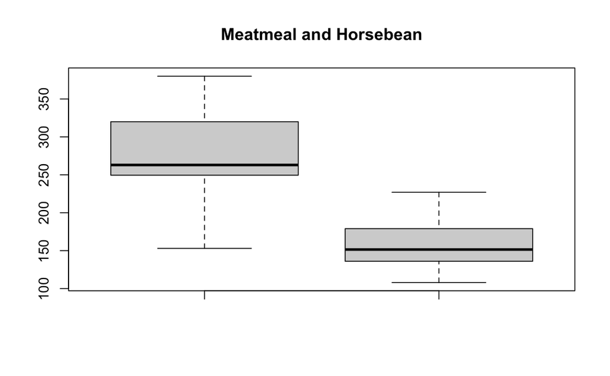

```r
boxplot(meat, horse, main = "Meatmeal and Horsebean")
```

Remember, our goal for this lecture is to determine if 2 samples are similar ( meaning that they come from the same underlying distribution ) or different ( meaning that they come from different underlying distributions ). Your box plot is helping shine light on that goal. We see that the bulk of the chickens in meatmeal, from the first quartile onward, weigh more than all the chickens that had the horsebean feed supplement.

order meatmeal from smallest weight to greatest weight and likewise order horsebean from smallest weight to greatest weight.

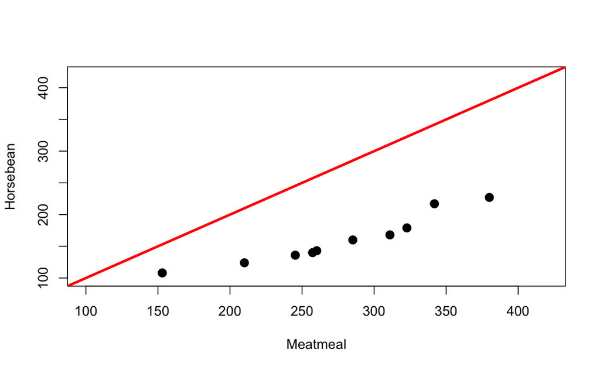

```r
qqplot(meat, horse, xlim=c(100, 420), xlab = "Meatmeal", ylab = "Horsebean", ylim = c(100, 420), pch = 20, cex=2)
abline(a=0, b=1, lwd= 3, col = "red")
```

Our graphical data analysis is leading us to believe that there might be a difference in chicken weight due to feed. But to draw that conclusion statistically, we can’t just look at the descriptive statistics. We have to do a formal statistical test—in this case, a hypothesis test.

H0 is that the 2 samples are from the same distribution ( and have the same mean ).

```r
H_0: mu_meat ~ mu_horse
```

```
H_0:mu_meat ~ mu_horse
```

Testing μmeat = μhorse is equivalent to testing

```r
mu_meat ~ mu_horse ~ H_0: mu_meat - mu_horse ~ 0
```

```
mu_meat ~ mu_horse ~ H_0:mu_meat - mu_horse ~ 0
```

The test statistic to use is the difference between sample mean and rescale that by the variance.

```r
X_mean ~ X_horse
```

```
X_mean ~ X_horse
```

A 2-sample t-test lets us determine whether the means of 2 independent data samples are different from one another. In a 2-sample test, the null hypothesis is that the means of both groups are the same. Unlike the 1-sample test ( where we test against a known population parameter ), the 2-sample test only involves sample means.

You might sometimes see this method referred to as Welch’s t-test because it deals with comparing 2 samples, as opposed to Student’s t-test, which is for 1 sample.

Here we’ve taken the mean and standard deviation of meatmeal and horsebean and calculated our test statistic, T. The value that we get is 5.059.

```r
mean_meat <- mean(meat)
mean_horse <- mean(horse)

sd_meat <-  sd(meat) / sqrt(length(meat))
sd_horse <-  sd(horse) / sqrt(length(horse))
```

```r
T_stat <- (mean_meat - mean_horse) / sqrt(sd_meat^2 + sd_horse^2)
T_stat
```

```
[1] 5.059444
```

R does the heavy lifting for you with the “t.test” function. The command is “t.test( meat, horse ),” and it returns the Welch’s 2-sample t-test.

We can confirm our test statistic value of 5.059, and we have a very low 𝑝-value, which would lead us to reject the null hypothesis that the 2 means are equal.

```r
t.test(meat, horse)
```

```
    Welch Two Sample t-test

data:  meat and horse
t = 5.0594, df = 16.524, p-value = 0.0001054
alternative hypothesis: true difference in means is not equal to 0
95 percent confidence interval:
  67.93364 165.48454
sample estimates:
mean of x mean of y
 276.9091  160.2000
```

### PAIRED T-TESTS

The 2-sample t-test procedure only applies when the 2 samples are independent and the underlying distributions are normal, as in our chicken weight example.

But what if we want to do a hypothesis test on data that’s related— dependent data? An example would be a person’s cholesterol level before and after being on a low-fat diet. In this case, we use a paired t-test, which helps us compare 2 samples where observations from one sample can be paired with observations from the other sample.

The paired-sample t-test works the same as a 1-sample t-test, but each observation in one sample is correlated to an observation in the second sample.

For example, the “IceSkating” dataset in the R package called “PairedData” gives the speed measurement ( in meters per second ) for 7 ice-skating dancers when 1 leg was either extended ( extension ) or flexed ( flexion ).

|  | Subject | Extension | Flexion |
| --- | --- | --- | --- |
| 1 | S1 | 2.13 | 1.90 |
| 2 | S2 | 1.77 | 1.55 |
| 3 | S3 | 1.68 | 1.62 |
| 4 | S4 | 2.04 | 1.89 |
| 5 | S5 | 2.12 | 2.01 |
| 6 | S6 | 1.92 | 1.91 |
| 7 | S7 | 2.08 | 2.10 |

Our summary statistics give us an idea of the spread of the data. Extension ranges from 1.68 to 2.13 meters per second with a mean of 1.963, and flexion ranges from 1.55 to 2.1 meters per second with a mean of 1.854.

```r
summary(IceSkating)
```

```
   Subject            Extension        Flexion
 Length:7           Min.   :1.680   Min.   :1.550
 Class :character   1st Qu.:1.845   1st Qu.:1.755
 Mode  :character   Median :2.040   Median :1.900
                    Mean   :1.963   Mean   :1.854
                    3rd Qu.:2.100   3rd Qu.:1.960
                    Max.   :2.130   Max.   :2.100
```

s there a difference in speed when the leg is extended versus flexed?

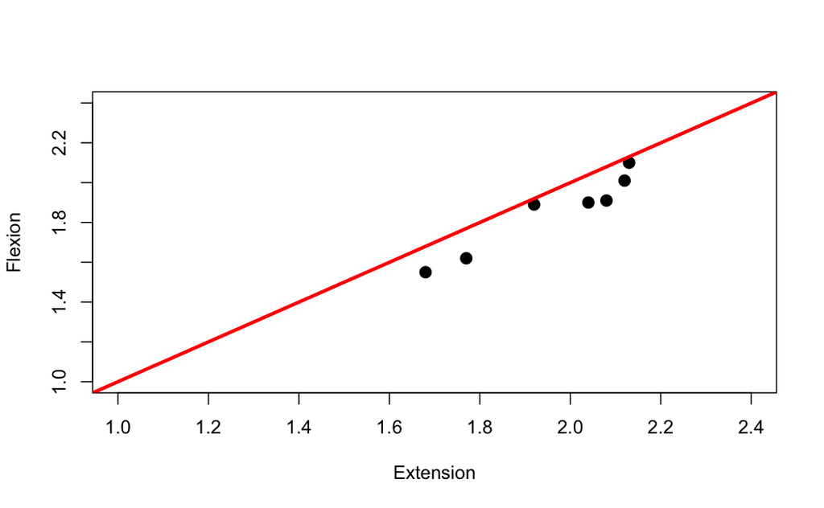

```r
qqplot(IceSkating$Extension, IceSkating$Flexion, xlim=c(1.0, 2.4), xlab = "Extension", ylab = "Flexion", ylim = c(1.0, 2.4), pch = 20, cex=2)
abline(a=0, b=1, lwd= 3, col = "red")
```

We can also look at the before and after measurements by subjects. In the following plot, we’ve sorted the subjects from least to greatest ( in terms of average speed ) along the 𝑦-axis, and their before and after measurements are plotted with extension in red and flexion in blue. In R, we use the following command.

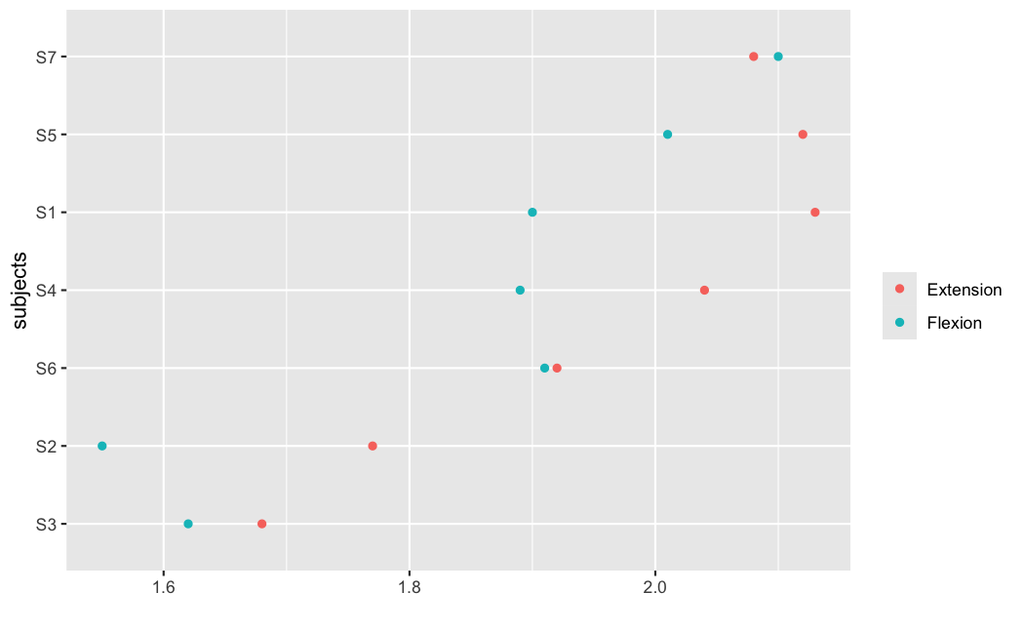

```r
with(IceSkating, plot(paired(Extension, Flexion), type= "McNeil"))
```

One main assumption for the paired t-test is that the differences of the pairs should follow a normal distribution, so we should check that assumption. Actually, our original data no longer has to satisfy the normality constraint. We’re not directly using those data values in the t-test—only their differences.

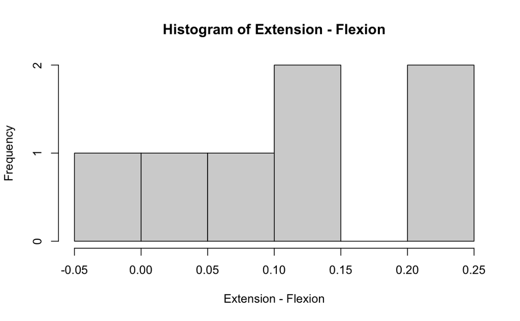

Because we only have 7 points, this histogram doesn’t really help us see if the data’s normal.

A quantile-quantile ( Q-Q ) plot of the difference looks much better. Notice how our points fall nicely along the line. And we can confirm with the Shapiro-Wilk test, which gives us a 𝑝-value of 0.6137.

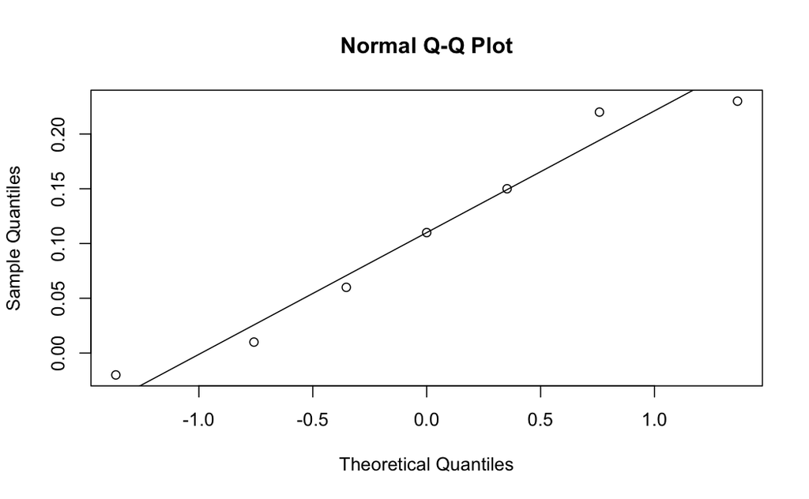

```r
with(IceSkating, qqnorm(Extension - Flexion))
with(IceSkating, qqline(Extension - Flexion))
```

```r
shapiro.test(Extension - Flexion)
```

```
    Shapiro-Wilk normality test

data:  Extension - Flexion
W = 0.93721, p-value = 0.6137
```

Let’s walk through some of the details of the paired t-test. For each matched pair, we create a new variable, d, which represents the difference between the 2 samples: d = Extension − Flexion. In R, we assign d to the difference in speed between extension and flexion.

```r
d = Extension - Flexion
d
```

```
[1]  0.23  0.22  0.06  0.15  0.11  0.01 -0.02
```

If there’s no difference in speed when the leg is extended versus flexed, then we would expect the means of the 2 groups to be equal:

```r
mean_ex ~ mu_fl
```

```
mean_ex ~ mu_fl
```

We can quickly verify that mean( Extension ) − mean( Flexion ) = mean( d ).

```r
mean(Extension) - mean(Flexion)
```

```
[1] 0.1085714
```

```r
mean(d)
```

```
[1] 0.1085714
```

```r
abs(qt(0.05/2, 6))
```

```
[1] 2.446912
```

```r
abs(qt(0.01/2, 6))
```

```
[1] 3.707428
```

Notice that at the 95% confidence level, we reject the null hypothesis because T > 2.45. We would conclude that there is a difference in speed when the leg is extended versus flexed.

But at the 99% confidence level, we fail to reject the null because T < 3.71. This is where the 𝑝-value’s importance is critical, because it tells us exactly where the cutoff is for this particular sample.

In R, the function “pt” gives the value of the t-distribution at our calculated t-statistic with 𝑛 − 1 ( the number of groups − 1 ) degrees of freedom. We multiple by 2 because it’s a 2-sided test.

```r
2 * (1 - pt(2.9346765, 6))
```

```
[1] 0.02612775
```

We can compare this to the output that R gives us. Notice that our 𝑝-value of 0.026 matches the result that we get from R

```r
t.test(Extension, Flexion, paired = TRUE)
```

```
    Paired t-test

data:  Extension and Flexion
t = 2.9347, df = 6, p-value = 0.02613
alternative hypothesis: true mean difference is not equal to 0
95 percent confidence interval:
 0.01804536 0.19909749
sample estimates:
mean difference
      0.1085714
```

```r
t.test(Extension,Flexion)
```

```
    Welch Two Sample t-test

data:  Extension and Flexion
t = 1.0731, df = 11.857, p-value = 0.3046
alternative hypothesis: true difference in means is not equal to 0
95 percent confidence interval:
 -0.1121619  0.3293047
sample estimates:
mean of x mean of y
 1.962857  1.854286
```

**If the differences between pairs are non-normal, don’t use the t-test for that. Your results won’t be valid.**

In this case, it would be better to use a non-parametric test, such as the Wilcoxon signed-rank test, which doesn’t depend on an underlying assumption of normality.